# Model fitting and calibration

Forrest W. Crawford

# Overview

## Fitting a model

Suppose we have formulated a dynamic model for a particular problem of interest. We observe some data corresponding to model compartments.

Our goal is to use the data to learn about the parameters of our model, so that its dynamics closely approximate the data.

Our hope is that if we use data to learn about the dyanmics of the model (internal validity), we can change some of the parameters or structure of the model and get valid estimates of what would happen under counterfactual scenarios (external validity).

## Formalism and notation

Suppose $\hat y_i$ is a data point, observed at time $t_i$, for $i=1,\ldots,n$.

Suppose we have formulated a model, that captures the mechanism of interest that produces the data.

Let $\theta$ be a parameter vector for the model, and let the model output with $\theta$ be $y_i(t|\theta)$. This is the prediction with a specific value of $t$ and $\theta$ plugged in.

## Fitting notation

We want to learn about a parameter vector $\theta$. How should we do this? By choosing $\theta$ to make the model output $y_i(t_i|\theta)$ look like the observed data $\hat y_i$ for times $t_1,\ldots,t_n$.

What does “look like” mean? What does it mean for two numbers to be “close together”? There are many answers to this question, but we will take the simplest one here.

Notation: in general we will use Greek letters for parameters that we want to calibrate or fit: $\alpha$, $\beta$, $\gamma$, $\theta$, $\epsilon$.

# Least squares

## Fitting deterministic models by least squares

Consider the general “loss” function
$$L(\theta) = \sum_{i=1}^n (y(t_i|\theta) - \hat y_i)^2$$

This is a sum of differences between the model output $y(t_i|\theta)$ and the observation $\hat y_i$, squared. Why squared? Because squaring this difference makes the result positive, and gives larger values to larger deviations.

$L(\theta)$ is big when the model fits the data badly, and near zero when it fits the data well.

We want to choose $\theta$ to make this loss function $L(\theta)$ as small as possible. The value of $\theta$ that makes $L(\theta)$ smallest will be our estimate of $\theta$.

## Example: deterministic SI model

Example: Suppose we have a SI system characterized by the deterministic ODE
$$\frac{dI}{dt} = \beta S(t) I(t)$$
and $N = S(t) + I(t)$ is known. Recall that for known $I(0)=i_0$, we can solve for $I(t)$ exactly at time points $t_1,\ldots,t_n$. For a particular value of $\beta$, call this solution $I(t|\beta)$.

Suppose we observe the number of infected individuals $\hat{I}(t_i)$ at times $0,t_1,\ldots,t_n$. We wish to use the observed data to estimate $\beta$ by making the model output $I(t_i|\beta)$ as close as possible to the real data $\hat{I}(t_i)$. The loss function is
$$L(\beta) = \sum_{j=1}^n (\hat I_j - I(t_j|\beta))^2$$
where $I(t_j,\beta)$ is the values of $I(t)$ at $t_j$ using parameter value $\beta$ obtained by numerical solution. The value of $\beta$ that minimizes $L(\beta)$ is our estimate of $\beta$.

## Illustration: deterministic SI model

Let’s generate data from the deterministic SI model, and add some “noise” to the infection output. Then we will try to estimate $\beta$ using the recipe outlined above.

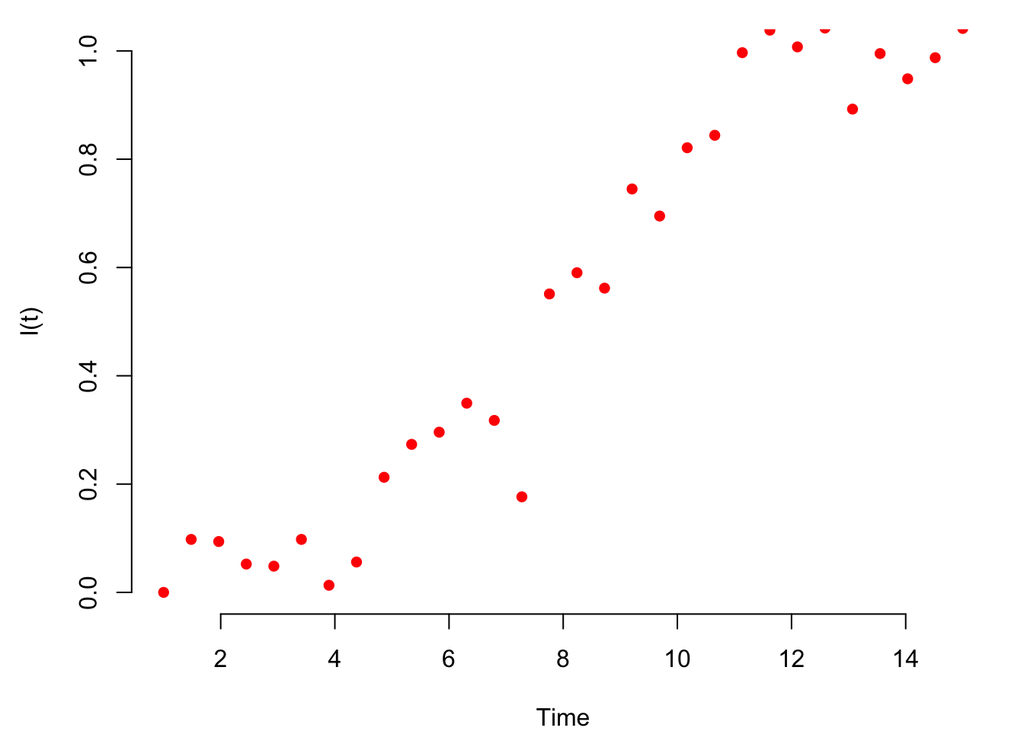

## Illustration: loss function

The loss function $L(\beta)$ has a global minimum.

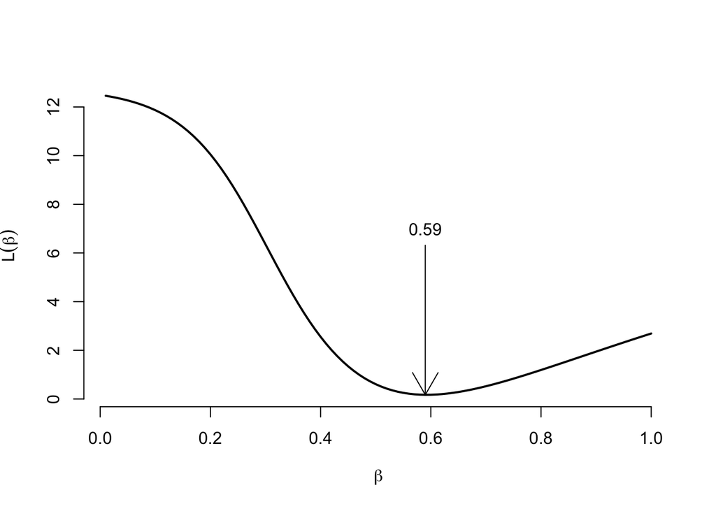

## Illustration: model fit

When we run the model forward using our “optimal” value of $\beta$, it seems to fit the well.

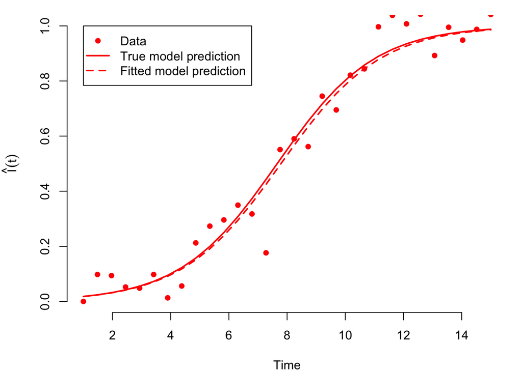

# Maximum likelihood

## Fitting deterministic models with statistical error distributions

Deterministic models produce a single trajectory for model compartments. But real data are noisy and bumpy. We can hypothesize a probability model for how error enters the model output and use that model to construct the loss function.

For example, some researchers assume that the observed count is a Poisson random variable whose mean is the true compartment value in the deterministic model. For the $I$ compartment,
$$\hat{I}(t) \sim \text{Poisson}(I(t|\beta))$$
Sometimes the error is modeled as Gaussian, or normal,
$$\hat{I}(t) \sim \text{Normal}(I(t|\beta), \sigma^2)$$

## Maximum likelihood

Let’s look at the Poisson case. The *likelihood* is the product of Poisson probabilities

$$\text{Likelihood}(\beta) = \prod_{i=1}^n \frac{I(t_i|\beta)^{\hat{I}(t_i)} \exp[-I(t_i|\beta)]}{\hat{I}(t_i)!}$$

and the loss function is the negative log-likelihood,

$$L(\beta) = -\sum_{i=1}^n \hat{I}(t_i) \log(I(t_i|\beta)) - I(t_i|\beta)$$

where $I(t,\beta)$ is the solution to the system.

# Fitting more complicated models

## When there are several parameters

Once you have a model that you can solve (on a computer) for a given set of input parameter values and you have defined a loss function that tells you what a “good” set of parameters looks like, you need to find the parameters that minimize the loss function. However, not all loss functions have a unique minimum.

When there is more than one or two unknown parameters, it can be difficult to visualize or search the space of values for the minimum of the loss function.

In this situation, you can’t just look at the loss function evaluated at several values of the parameter. You need to use a computer program to find the value of $\theta$ that minimizes $L(\theta)$.

R provides several functions for nonlinear optimization, but the most useful is `nlm`. Here is an example:

## Using `nlm` for nonlinear minimization

Consider a deterministic SIR trajectory with noise/errors added. Suppose we only observe the data (dots) at discrete time intervals. How can we learn about $\beta$ and $\gamma$?

```r
library(deSolve)
sir <- function(time, state, parameters) {
    with(as.list(c(state, parameters)), {
        dS <- -beta * S * I
        dI <- beta * S * I - gamma * I
        dR <- gamma * I
        return(list(c(dS, dI, dR)))
    })
}
```

## Running the model

```r
init <- c(S = 1 - 1e-06, I = 1e-06, R = 0)
parameters <- c(beta = 1.4, gamma = 0.14)
times <- seq(0, 50, by = 1)
out <- as.data.frame(ode(y = init, times = times,
    func = sir, parms = parameters))
S_obs = rnorm(length(times), out$S, sd = 0.1)
I_obs = rnorm(length(times), out$I, sd = 0.1)
R_obs = rnorm(length(times), out$R, sd = 0.1)
```

## Plotting the model output

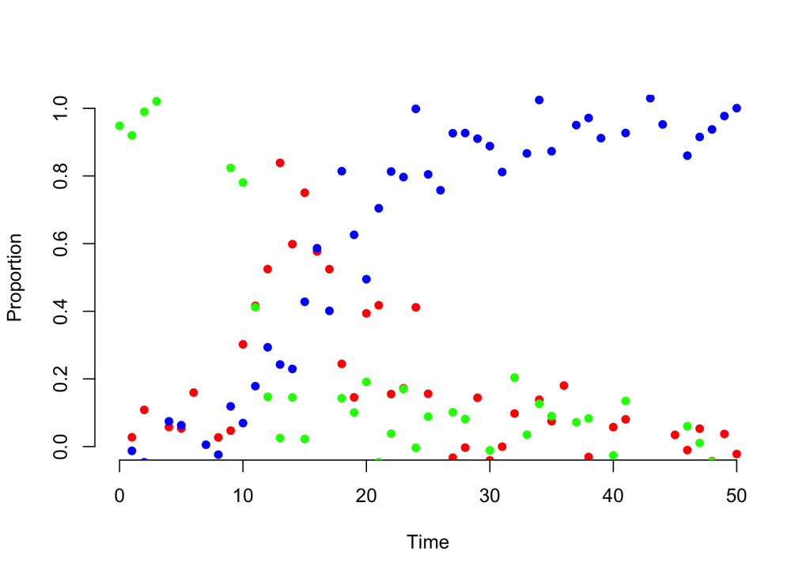

```r
plot(out$time, I_obs, ylab = "Proportion",
    xlab = "Time", pch = 16, bty = "n", ylim = c(0,
        1), col = "red")
points(out$time, S_obs, pch = 16, col = "green")
points(out$time, R_obs, pch = 16, col = "blue")
legend(70, 0.5, c("S(t)", "I(t)", "R(t)"),
    pch = 16, col = c("green", "red", "blue"))
```

## Fitting

We set up a loss function which is a function of the unknown parameters $\beta$ and $\gamma$, then try to minimize it. `nlm` returns several quantities; the `estimate` is the one you want. The `code` should be 1 or 2 when `nlm` thinks it has found a local minimum. See `?nlm` for details.

```r
loss = function(params) {
    names(params) = c("beta", "gamma")
    out <- as.data.frame(ode(y = init, times = times,
        func = sir, parms = params))
    sum((out$S - S_obs)^2 + (out$I - I_obs)^2 +
        (out$R - R_obs)^2)
}
fit = nlm(loss, p = parameters, stepmax = 0.05)
```

## `nlm` output

```r
parameters
```

```
##  beta gamma
##  1.40  0.14
```

```r
fit
```

```
## $minimum
## [1] 1.686714
##
## $estimate
## [1] 1.394660 0.137014
##
## $gradient
## [1] -9.455514e-07  6.927792e-08
##
## $code
## [1] 1
##
## $iterations
## [1] 7
```

## Fitted trajectories

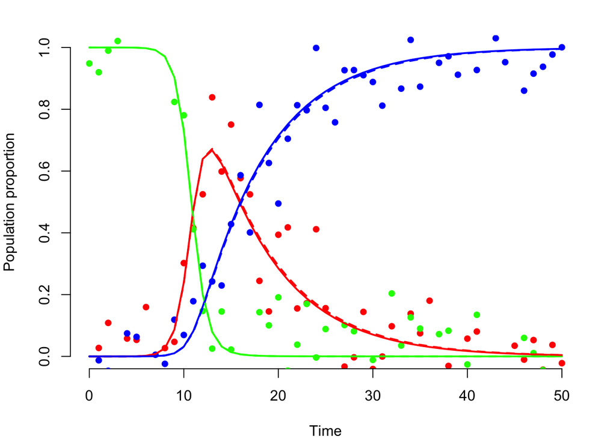

## Using `nlm`

Generic optimization routines like `nlm` work best when the loss function is *convex* (U-shaped) and fairly smooth (differentiable).

It works by trying to pick parameter values that go “downhill” in the loss function at each step.

But in general, there is no guarantee that `nlm` will arrive at a global minimum of the loss function. You may have to try it using several (possibly random) starting values and see where it goes.

## Non-identifiable parameters

Sometimes you do not have enough data to tell you about some of the parameters in your model.

In this case, in order to use the model to make predictions, you will need to set these parameters to particular values. There are several strategies for doing this:

1. Make up values that seem reasonable
2. Pick values from the scientific literature
3. Pick an interval, or probability distribution, in which you think the parameters lie

When you do this, your model output may depend a lot on which values you use, and it is important to assess the sensitivity of your model to these parameter assumptions.

## Not covered

There is a whole scientific field concerned with getting good estimates of $\theta$ given data. Much of it is concerned with estimates of uncertainty in parameters given noisy data. This field is called *statistics*.

We are not covering any details of

- Maximum likelihood estimation
- Frequentist methods
- Bayesian methods
- Probabilistic representations of uncertainty
- Asymptotic approximation

See Wasserman (2013) for the rest.

## References

Wasserman, Larry. 2013. *All of Statistics: A Concise Course in Statistical Inference*. Springer Science & Business Media.